# Risk Factor Analysis

## Outcome Variable

**Outcome Variable:** ever_co

## Predictor Variables

**Intervention Variable:** nchldlt5

**Adjustment Set:**

- arm
- W_mage
- meducyrs
- feducyrs
- hhwealth_quart
- hfoodsec
- W_mhtcm
- W_nrooms
- W_parity
- impfloor
- impsan
- safeh20
- delta_W_mage
- delta_meducyrs
- delta_feducyrs
- delta_hhwealth_quart
- delta_hfoodsec
- delta_W_mhtcm
- delta_W_nrooms
- delta_W_parity
- delta_impfloor
- delta_impsan
- delta_safeh20

## Stratifying Variables

The analysis was stratified on these variable(s):

- agecat
- studyid
- country

## Data Summary

| agecat | studyid | country | nchldlt5 | ever_co | n_cell | n |
| --- | --- | --- | --- | --- | --- | --- |
| 0-24 months | ki1000108-IRC | INDIA | 1 | 0 | 69 | 291 |
| 0-24 months | ki1000108-IRC | INDIA | 1 | 1 | 20 | 291 |
| 0-24 months | ki1000108-IRC | INDIA | 2+ | 0 | 165 | 291 |
| 0-24 months | ki1000108-IRC | INDIA | 2+ | 1 | 37 | 291 |
| 0-24 months | ki1017093b-PROVIDE | BANGLADESH | 1 | 0 | 447 | 524 |
| 0-24 months | ki1017093b-PROVIDE | BANGLADESH | 1 | 1 | 65 | 524 |
| 0-24 months | ki1017093b-PROVIDE | BANGLADESH | 2+ | 0 | 11 | 524 |
| 0-24 months | ki1017093b-PROVIDE | BANGLADESH | 2+ | 1 | 1 | 524 |
| 0-24 months | ki1017093c-NIH-Crypto | BANGLADESH | 1 | 0 | 496 | 547 |
| 0-24 months | ki1017093c-NIH-Crypto | BANGLADESH | 1 | 1 | 45 | 547 |
| 0-24 months | ki1017093c-NIH-Crypto | BANGLADESH | 2+ | 0 | 6 | 547 |
| 0-24 months | ki1017093c-NIH-Crypto | BANGLADESH | 2+ | 1 | 0 | 547 |
| 0-24 months | ki1066203-TanzaniaChild2 | TANZANIA, UNITED REPUBLIC OF | 1 | 0 | 1552 | 1716 |
| 0-24 months | ki1066203-TanzaniaChild2 | TANZANIA, UNITED REPUBLIC OF | 1 | 1 | 85 | 1716 |
| 0-24 months | ki1066203-TanzaniaChild2 | TANZANIA, UNITED REPUBLIC OF | 2+ | 0 | 77 | 1716 |
| 0-24 months | ki1066203-TanzaniaChild2 | TANZANIA, UNITED REPUBLIC OF | 2+ | 1 | 2 | 1716 |
| 0-24 months | ki1112895-iLiNS-Zinc | BURKINA FASO | 1 | 0 | 956 | 1916 |
| 0-24 months | ki1112895-iLiNS-Zinc | BURKINA FASO | 1 | 1 | 117 | 1916 |
| 0-24 months | ki1112895-iLiNS-Zinc | BURKINA FASO | 2+ | 0 | 714 | 1916 |
| 0-24 months | ki1112895-iLiNS-Zinc | BURKINA FASO | 2+ | 1 | 129 | 1916 |
| 0-24 months | ki1148112-LCNI-5 | MALAWI | 1 | 0 | 376 | 454 |
| 0-24 months | ki1148112-LCNI-5 | MALAWI | 1 | 1 | 15 | 454 |
| 0-24 months | ki1148112-LCNI-5 | MALAWI | 2+ | 0 | 60 | 454 |
| 0-24 months | ki1148112-LCNI-5 | MALAWI | 2+ | 1 | 3 | 454 |
| 0-24 months | kiGH5241-JiVitA-3 | BANGLADESH | 1 | 0 | 15663 | 17829 |
| 0-24 months | kiGH5241-JiVitA-3 | BANGLADESH | 1 | 1 | 1535 | 17829 |
| 0-24 months | kiGH5241-JiVitA-3 | BANGLADESH | 2+ | 0 | 578 | 17829 |
| 0-24 months | kiGH5241-JiVitA-3 | BANGLADESH | 2+ | 1 | 53 | 17829 |
| 0-6 months | ki1000108-IRC | INDIA | 1 | 0 | 79 | 290 |
| 0-6 months | ki1000108-IRC | INDIA | 1 | 1 | 10 | 290 |
| 0-6 months | ki1000108-IRC | INDIA | 2+ | 0 | 192 | 290 |
| 0-6 months | ki1000108-IRC | INDIA | 2+ | 1 | 9 | 290 |
| 0-6 months | ki1017093b-PROVIDE | BANGLADESH | 1 | 0 | 491 | 524 |
| 0-6 months | ki1017093b-PROVIDE | BANGLADESH | 1 | 1 | 21 | 524 |
| 0-6 months | ki1017093b-PROVIDE | BANGLADESH | 2+ | 0 | 11 | 524 |
| 0-6 months | ki1017093b-PROVIDE | BANGLADESH | 2+ | 1 | 1 | 524 |
| 0-6 months | ki1017093c-NIH-Crypto | BANGLADESH | 1 | 0 | 531 | 547 |
| 0-6 months | ki1017093c-NIH-Crypto | BANGLADESH | 1 | 1 | 10 | 547 |
| 0-6 months | ki1017093c-NIH-Crypto | BANGLADESH | 2+ | 0 | 6 | 547 |
| 0-6 months | ki1017093c-NIH-Crypto | BANGLADESH | 2+ | 1 | 0 | 547 |
| 0-6 months | ki1066203-TanzaniaChild2 | TANZANIA, UNITED REPUBLIC OF | 1 | 0 | 1622 | 1716 |
| 0-6 months | ki1066203-TanzaniaChild2 | TANZANIA, UNITED REPUBLIC OF | 1 | 1 | 15 | 1716 |
| 0-6 months | ki1066203-TanzaniaChild2 | TANZANIA, UNITED REPUBLIC OF | 2+ | 0 | 79 | 1716 |
| 0-6 months | ki1066203-TanzaniaChild2 | TANZANIA, UNITED REPUBLIC OF | 2+ | 1 | 0 | 1716 |
| 0-6 months | ki1148112-LCNI-5 | MALAWI | 1 | 0 | 122 | 145 |
| 0-6 months | ki1148112-LCNI-5 | MALAWI | 1 | 1 | 0 | 145 |
| 0-6 months | ki1148112-LCNI-5 | MALAWI | 2+ | 0 | 23 | 145 |
| 0-6 months | ki1148112-LCNI-5 | MALAWI | 2+ | 1 | 0 | 145 |
| 0-6 months | kiGH5241-JiVitA-3 | BANGLADESH | 1 | 0 | 16387 | 17741 |
| 0-6 months | kiGH5241-JiVitA-3 | BANGLADESH | 1 | 1 | 725 | 17741 |
| 0-6 months | kiGH5241-JiVitA-3 | BANGLADESH | 2+ | 0 | 606 | 17741 |
| 0-6 months | kiGH5241-JiVitA-3 | BANGLADESH | 2+ | 1 | 23 | 17741 |
| 6-24 months | ki1000108-IRC | INDIA | 1 | 0 | 73 | 291 |
| 6-24 months | ki1000108-IRC | INDIA | 1 | 1 | 16 | 291 |
| 6-24 months | ki1000108-IRC | INDIA | 2+ | 0 | 169 | 291 |
| 6-24 months | ki1000108-IRC | INDIA | 2+ | 1 | 33 | 291 |
| 6-24 months | ki1017093b-PROVIDE | BANGLADESH | 1 | 0 | 396 | 458 |
| 6-24 months | ki1017093b-PROVIDE | BANGLADESH | 1 | 1 | 52 | 458 |
| 6-24 months | ki1017093b-PROVIDE | BANGLADESH | 2+ | 0 | 9 | 458 |
| 6-24 months | ki1017093b-PROVIDE | BANGLADESH | 2+ | 1 | 1 | 458 |
| 6-24 months | ki1017093c-NIH-Crypto | BANGLADESH | 1 | 0 | 481 | 525 |
| 6-24 months | ki1017093c-NIH-Crypto | BANGLADESH | 1 | 1 | 39 | 525 |
| 6-24 months | ki1017093c-NIH-Crypto | BANGLADESH | 2+ | 0 | 5 | 525 |
| 6-24 months | ki1017093c-NIH-Crypto | BANGLADESH | 2+ | 1 | 0 | 525 |
| 6-24 months | ki1066203-TanzaniaChild2 | TANZANIA, UNITED REPUBLIC OF | 1 | 0 | 1303 | 1447 |
| 6-24 months | ki1066203-TanzaniaChild2 | TANZANIA, UNITED REPUBLIC OF | 1 | 1 | 80 | 1447 |
| 6-24 months | ki1066203-TanzaniaChild2 | TANZANIA, UNITED REPUBLIC OF | 2+ | 0 | 62 | 1447 |
| 6-24 months | ki1066203-TanzaniaChild2 | TANZANIA, UNITED REPUBLIC OF | 2+ | 1 | 2 | 1447 |
| 6-24 months | ki1112895-iLiNS-Zinc | BURKINA FASO | 1 | 0 | 956 | 1916 |
| 6-24 months | ki1112895-iLiNS-Zinc | BURKINA FASO | 1 | 1 | 117 | 1916 |
| 6-24 months | ki1112895-iLiNS-Zinc | BURKINA FASO | 2+ | 0 | 714 | 1916 |
| 6-24 months | ki1112895-iLiNS-Zinc | BURKINA FASO | 2+ | 1 | 129 | 1916 |
| 6-24 months | ki1148112-LCNI-5 | MALAWI | 1 | 0 | 369 | 446 |
| 6-24 months | ki1148112-LCNI-5 | MALAWI | 1 | 1 | 15 | 446 |
| 6-24 months | ki1148112-LCNI-5 | MALAWI | 2+ | 0 | 59 | 446 |
| 6-24 months | ki1148112-LCNI-5 | MALAWI | 2+ | 1 | 3 | 446 |
| 6-24 months | kiGH5241-JiVitA-3 | BANGLADESH | 1 | 0 | 10266 | 11565 |
| 6-24 months | kiGH5241-JiVitA-3 | BANGLADESH | 1 | 1 | 924 | 11565 |
| 6-24 months | kiGH5241-JiVitA-3 | BANGLADESH | 2+ | 0 | 340 | 11565 |
| 6-24 months | kiGH5241-JiVitA-3 | BANGLADESH | 2+ | 1 | 35 | 11565 |

The following strata were considered:

- agecat: 0-24 months, studyid: ki1000108-IRC, country: INDIA
- agecat: 0-24 months, studyid: ki1017093b-PROVIDE, country: BANGLADESH
- agecat: 0-24 months, studyid: ki1017093c-NIH-Crypto, country: BANGLADESH
- agecat: 0-24 months, studyid: ki1066203-TanzaniaChild2, country: TANZANIA, UNITED REPUBLIC OF
- agecat: 0-24 months, studyid: ki1112895-iLiNS-Zinc, country: BURKINA FASO
- agecat: 0-24 months, studyid: ki1148112-LCNI-5, country: MALAWI
- agecat: 0-24 months, studyid: kiGH5241-JiVitA-3, country: BANGLADESH
- agecat: 0-6 months, studyid: ki1000108-IRC, country: INDIA
- agecat: 0-6 months, studyid: ki1017093b-PROVIDE, country: BANGLADESH
- agecat: 0-6 months, studyid: ki1017093c-NIH-Crypto, country: BANGLADESH
- agecat: 0-6 months, studyid: ki1066203-TanzaniaChild2, country: TANZANIA, UNITED REPUBLIC OF
- agecat: 0-6 months, studyid: ki1148112-LCNI-5, country: MALAWI
- agecat: 0-6 months, studyid: kiGH5241-JiVitA-3, country: BANGLADESH
- agecat: 6-24 months, studyid: ki1000108-IRC, country: INDIA
- agecat: 6-24 months, studyid: ki1017093b-PROVIDE, country: BANGLADESH
- agecat: 6-24 months, studyid: ki1017093c-NIH-Crypto, country: BANGLADESH
- agecat: 6-24 months, studyid: ki1066203-TanzaniaChild2, country: TANZANIA, UNITED REPUBLIC OF
- agecat: 6-24 months, studyid: ki1112895-iLiNS-Zinc, country: BURKINA FASO
- agecat: 6-24 months, studyid: ki1148112-LCNI-5, country: MALAWI
- agecat: 6-24 months, studyid: kiGH5241-JiVitA-3, country: BANGLADESH

### Dropped Strata

Some strata were dropped due to rare outcomes:

- agecat: 0-24 months, studyid: ki1017093b-PROVIDE, country: BANGLADESH
- agecat: 0-24 months, studyid: ki1017093c-NIH-Crypto, country: BANGLADESH
- agecat: 0-24 months, studyid: ki1066203-TanzaniaChild2, country: TANZANIA, UNITED REPUBLIC OF
- agecat: 0-24 months, studyid: ki1148112-LCNI-5, country: MALAWI
- agecat: 0-6 months, studyid: ki1017093b-PROVIDE, country: BANGLADESH
- agecat: 0-6 months, studyid: ki1017093c-NIH-Crypto, country: BANGLADESH
- agecat: 0-6 months, studyid: ki1066203-TanzaniaChild2, country: TANZANIA, UNITED REPUBLIC OF
- agecat: 0-6 months, studyid: ki1148112-LCNI-5, country: MALAWI
- agecat: 6-24 months, studyid: ki1017093b-PROVIDE, country: BANGLADESH
- agecat: 6-24 months, studyid: ki1017093c-NIH-Crypto, country: BANGLADESH
- agecat: 6-24 months, studyid: ki1066203-TanzaniaChild2, country: TANZANIA, UNITED REPUBLIC OF
- agecat: 6-24 months, studyid: ki1148112-LCNI-5, country: MALAWI

## Methods Detail

We’re interested in the causal parameters $E[Y_a]$ for all values of $a \in \mathcal{A}$. These parameters represent the mean outcome if, possibly contrary to fact, we intervened to set all units to have $A=a$. Under the randomization and positivity assumptions, these are identified by the statistical parameters $\psi_a=E_W[E_{Y|A,W}(Y|A=a,W)]$. In addition, we’re interested in the mean of $Y$, $E[Y]$ under no intervention (the observed mean). We will estimate these parameters by using SuperLearner to fit the relevant likelihood factors – $E_{Y|A,W}(Y|A=a,W)$ and $p(A=a|W)$, and then updating our likelihood fit using a joint TMLE.

For unadjusted analyses ($W=\{\}$), initial likelihoods were estimated using Lrnr_glm to estimate the simple $E(Y|A)$ and Lrnr_mean to estimate $p(A)$. For adjusted analyses, a small library containing Lrnr_glmnet, Lrnr_xgboost, and Lrnr_mean was used.

Having estimated these parameters, we will then use the delta method to estimate relative risks and attributable risks relative to a prespecified baseline level of $A$.

# Results Detail

## Results Plots

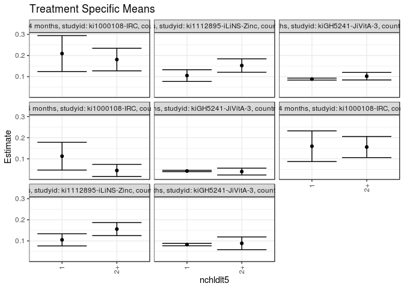

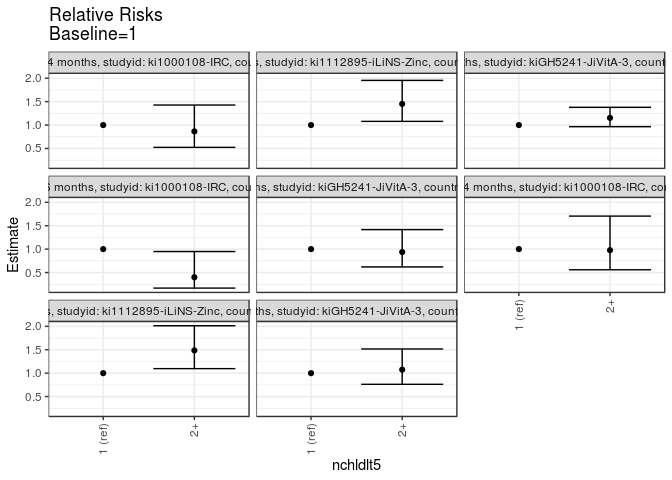

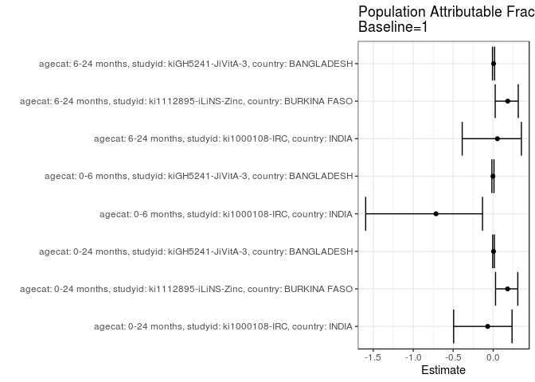

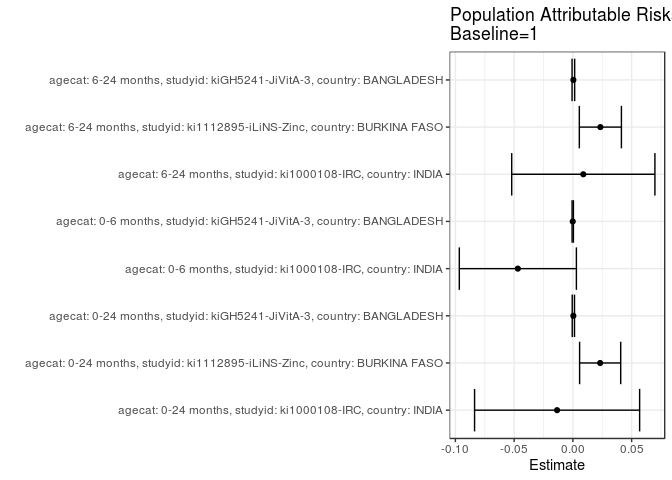

## Results Table

### Parameter: TSM

| agecat | studyid | country | intervention_level | baseline_level | estimate | ci_lower | ci_upper |
| --- | --- | --- | --- | --- | --- | --- | --- |
| 0-24 months | ki1000108-IRC | INDIA | 1 | NA | 0.2093207 | 0.1244008 | 0.2942407 |
| 0-24 months | ki1000108-IRC | INDIA | 2+ | NA | 0.1810296 | 0.1276656 | 0.2343936 |
| 0-24 months | ki1112895-iLiNS-Zinc | BURKINA FASO | 1 | NA | 0.1051964 | 0.0774250 | 0.1329678 |
| 0-24 months | ki1112895-iLiNS-Zinc | BURKINA FASO | 2+ | NA | 0.1527073 | 0.1209093 | 0.1845053 |
| 0-24 months | kiGH5241-JiVitA-3 | BANGLADESH | 1 | NA | 0.0886709 | 0.0839303 | 0.0934115 |
| 0-24 months | kiGH5241-JiVitA-3 | BANGLADESH | 2+ | NA | 0.1023023 | 0.0845181 | 0.1200864 |
| 0-6 months | ki1000108-IRC | INDIA | 1 | NA | 0.1123596 | 0.0466351 | 0.1780840 |
| 0-6 months | ki1000108-IRC | INDIA | 2+ | NA | 0.0447761 | 0.0161359 | 0.0734163 |
| 0-6 months | kiGH5241-JiVitA-3 | BANGLADESH | 1 | NA | 0.0422836 | 0.0391304 | 0.0454368 |
| 0-6 months | kiGH5241-JiVitA-3 | BANGLADESH | 2+ | NA | 0.0396099 | 0.0234380 | 0.0557818 |
| 6-24 months | ki1000108-IRC | INDIA | 1 | NA | 0.1595165 | 0.0869801 | 0.2320528 |
| 6-24 months | ki1000108-IRC | INDIA | 2+ | NA | 0.1557670 | 0.1059012 | 0.2056327 |
| 6-24 months | ki1112895-iLiNS-Zinc | BURKINA FASO | 1 | NA | 0.1050056 | 0.0762763 | 0.1337349 |
| 6-24 months | ki1112895-iLiNS-Zinc | BURKINA FASO | 2+ | NA | 0.1560559 | 0.1250861 | 0.1870257 |
| 6-24 months | kiGH5241-JiVitA-3 | BANGLADESH | 1 | NA | 0.0825224 | 0.0767798 | 0.0882650 |
| 6-24 months | kiGH5241-JiVitA-3 | BANGLADESH | 2+ | NA | 0.0887206 | 0.0586287 | 0.1188126 |

### Parameter: E(Y)

| agecat | studyid | country | intervention_level | baseline_level | estimate | ci_lower | ci_upper |
| --- | --- | --- | --- | --- | --- | --- | --- |
| 0-24 months | ki1000108-IRC | INDIA | NA | NA | 0.1958763 | 0.1501989 | 0.2415537 |
| 0-24 months | ki1112895-iLiNS-Zinc | BURKINA FASO | NA | NA | 0.1283925 | 0.1061546 | 0.1506304 |
| 0-24 months | kiGH5241-JiVitA-3 | BANGLADESH | NA | NA | 0.0890684 | 0.0844497 | 0.0936870 |
| 0-6 months | ki1000108-IRC | INDIA | NA | NA | 0.0655172 | 0.0369898 | 0.0940447 |
| 0-6 months | kiGH5241-JiVitA-3 | BANGLADESH | NA | NA | 0.0421622 | 0.0390671 | 0.0452573 |
| 6-24 months | ki1000108-IRC | INDIA | NA | NA | 0.1683849 | 0.1253162 | 0.2114536 |
| 6-24 months | ki1112895-iLiNS-Zinc | BURKINA FASO | NA | NA | 0.1283925 | 0.1061546 | 0.1506304 |
| 6-24 months | kiGH5241-JiVitA-3 | BANGLADESH | NA | NA | 0.0829226 | 0.0772615 | 0.0885837 |

### Parameter: RR

| agecat | studyid | country | intervention_level | baseline_level | estimate | ci_lower | ci_upper |
| --- | --- | --- | --- | --- | --- | --- | --- |
| 0-24 months | ki1000108-IRC | INDIA | 1 | 1 | 1.0000000 | 1.0000000 | 1.0000000 |
| 0-24 months | ki1000108-IRC | INDIA | 2+ | 1 | 0.8648432 | 0.5236968 | 1.4282190 |
| 0-24 months | ki1112895-iLiNS-Zinc | BURKINA FASO | 1 | 1 | 1.0000000 | 1.0000000 | 1.0000000 |
| 0-24 months | ki1112895-iLiNS-Zinc | BURKINA FASO | 2+ | 1 | 1.4516398 | 1.0785634 | 1.9537637 |
| 0-24 months | kiGH5241-JiVitA-3 | BANGLADESH | 1 | 1 | 1.0000000 | 1.0000000 | 1.0000000 |
| 0-24 months | kiGH5241-JiVitA-3 | BANGLADESH | 2+ | 1 | 1.1537305 | 0.9656555 | 1.3784357 |
| 0-6 months | ki1000108-IRC | INDIA | 1 | 1 | 1.0000000 | 1.0000000 | 1.0000000 |
| 0-6 months | ki1000108-IRC | INDIA | 2+ | 1 | 0.3985075 | 0.1674954 | 0.9481349 |
| 0-6 months | kiGH5241-JiVitA-3 | BANGLADESH | 1 | 1 | 1.0000000 | 1.0000000 | 1.0000000 |
| 0-6 months | kiGH5241-JiVitA-3 | BANGLADESH | 2+ | 1 | 0.9367678 | 0.6193253 | 1.4169192 |
| 6-24 months | ki1000108-IRC | INDIA | 1 | 1 | 1.0000000 | 1.0000000 | 1.0000000 |
| 6-24 months | ki1000108-IRC | INDIA | 2+ | 1 | 0.9764946 | 0.5590994 | 1.7054957 |
| 6-24 months | ki1112895-iLiNS-Zinc | BURKINA FASO | 1 | 1 | 1.0000000 | 1.0000000 | 1.0000000 |
| 6-24 months | ki1112895-iLiNS-Zinc | BURKINA FASO | 2+ | 1 | 1.4861674 | 1.0971776 | 2.0130683 |
| 6-24 months | kiGH5241-JiVitA-3 | BANGLADESH | 1 | 1 | 1.0000000 | 1.0000000 | 1.0000000 |
| 6-24 months | kiGH5241-JiVitA-3 | BANGLADESH | 2+ | 1 | 1.0751096 | 0.7620514 | 1.5167752 |

### Parameter: PAR

| agecat | studyid | country | intervention_level | baseline_level | estimate | ci_lower | ci_upper |
| --- | --- | --- | --- | --- | --- | --- | --- |
| 0-24 months | ki1000108-IRC | INDIA | 1 | NA | -0.0134445 | -0.0836870 | 0.0567981 |
| 0-24 months | ki1112895-iLiNS-Zinc | BURKINA FASO | 1 | NA | 0.0231961 | 0.0057113 | 0.0406808 |
| 0-24 months | kiGH5241-JiVitA-3 | BANGLADESH | 1 | NA | 0.0003975 | -0.0005756 | 0.0013706 |
| 0-6 months | ki1000108-IRC | INDIA | 1 | NA | -0.0468423 | -0.0966631 | 0.0029785 |
| 0-6 months | kiGH5241-JiVitA-3 | BANGLADESH | 1 | NA | -0.0001214 | -0.0006842 | 0.0004415 |
| 6-24 months | ki1000108-IRC | INDIA | 1 | NA | 0.0088684 | -0.0520711 | 0.0698080 |
| 6-24 months | ki1112895-iLiNS-Zinc | BURKINA FASO | 1 | NA | 0.0233869 | 0.0054802 | 0.0412936 |
| 6-24 months | kiGH5241-JiVitA-3 | BANGLADESH | 1 | NA | 0.0004002 | -0.0007096 | 0.0015100 |

### Parameter: PAF

| agecat | studyid | country | intervention_level | baseline_level | estimate | ci_lower | ci_upper |
| --- | --- | --- | --- | --- | --- | --- | --- |
| 0-24 months | ki1000108-IRC | INDIA | 1 | NA | -0.0686375 | -0.4945822 | 0.2359162 |
| 0-24 months | ki1112895-iLiNS-Zinc | BURKINA FASO | 1 | NA | 0.1806654 | 0.0296652 | 0.3081675 |
| 0-24 months | kiGH5241-JiVitA-3 | BANGLADESH | 1 | NA | 0.0044629 | -0.0065300 | 0.0153359 |
| 0-6 months | ki1000108-IRC | INDIA | 1 | NA | -0.7149615 | -1.5950707 | -0.1333383 |
| 0-6 months | kiGH5241-JiVitA-3 | BANGLADESH | 1 | NA | -0.0028785 | -0.0163162 | 0.0103814 |
| 6-24 months | ki1000108-IRC | INDIA | 1 | NA | 0.0526675 | -0.3872925 | 0.3531005 |
| 6-24 months | ki1112895-iLiNS-Zinc | BURKINA FASO | 1 | NA | 0.1821516 | 0.0254285 | 0.3136717 |
| 6-24 months | kiGH5241-JiVitA-3 | BANGLADESH | 1 | NA | 0.0048263 | -0.0086435 | 0.0181162 |